# Estudo de Caso: Efeito Coattail Presidencial nas Eleições Distritais do DF (2006–2022)

## INTRODUÇÃO

Este estudo de caso aplica o framework completo de análise de dados do **Google Data Analytics Certificate (Ask → Prepare → Process → Analyze → Share → Act)** para investigar o **efeito coattail presidencial** no contexto do Distrito Federal (DF).

Utilizando **R Studio** como ambiente principal de análise, com **R Markdown** para documentação reproduzível, **SQL no Google BigQuery** para extração eficiente de big data eleitoral, este projeto foca em uma métrica clara e intuitiva: a **correlação** entre os votos do candidato eleito à Presidência e os votos dos deputados distritais eleitos de seu partido ou coligação.

O período analisado abrange cinco eleições gerais (**2006, 2010, 2014, 2018 e 2022**), cobrindo um arco de transformação política marcada pela ascensão do PT, a crise de 2014–2016, o fenômeno Bolsonaro e o retorno de Lula — um ciclo completo de **polarização nacional crescente**.

### Objetivo Geral

Quantificar, de forma simples e clara, até que ponto o desempenho do presidente eleito “puxa” votos para deputados distritais da mesma coligação no DF, contribuindo para o debate sobre **polarização, alinhamento partidário vertical e autonomia do voto local**.

### Ferramentas e Tecnologias Utilizadas

- **Google BigQuery** + **SQL**: Extração eficiente e filtrada dos dados eleitorais tratados pela Base dos Dados.
- **R Studio** + **pacotes**: `tidyverse`, `ggplot2`, `corrr`, `scales`
- **R Markdown**: Relatório dinâmico, reproduzível e com gráficos interativos.
- **Google Sheets/CSV**: Validação intermediária e compartilhamento acessível.

### Relevância Prática

- **Para eleitores**: Entender se seu voto para deputado distrital é realmente “local” ou se reflete afetos nacionais.
- **Para campanhas de 2026**: Identificar RAs onde o coattail presidencial é forte ou fraco para estratégias de coligação.
- **Para cientistas políticos**: Evidência empírica simples sobre como a polarização nacional pode se manifestar até mesmo no voto legislativo local.

**O presente estudo seguirá rigorosamente as seis etapas do framework do Google Data Analytics Certificate**, com documentação completa, código aberto e resultados visualmente interpretáveis.

## PRIMEIRA ETAPA: ASK

### 1. Qual tópico estou explorando?

Esta análise investiga a existência do efeito coattail presidencial nas eleições para deputado da Câmara Legislativa do Distrito Federal entre 2006 e 2022, ou seja, até que ponto a votação do candidato que virou presidente “puxou” votos para os deputados distritais da mesma coligação.

### 2. Qual é a pergunta central que quero responder?

Em que medida o desempenho eleitoral do candidato vencedor à Presidência da República influencia o voto para deputados distritais no mesmo pleito. Em resumo: existe correlação forte entre o voto presidencial e o voto distrital?

### 3. Quais métricas usarei para mensurar meus dados e atingir meus objetivos?

Cálculo de correlação de votos válidos entre o presidente eleito e os deputados distritais eleitos.

### 4. Quem pode se interessar?

Eleitores do DF, jornalistas, cientistas políticos, candidatos e assessores de campanha de 2026

### 5. Como essa análise pode ajudar na tomada de decisão?

Mostrar de forma visual e acessível se existe influência do presidente eleito nos cargos de deputado distrital. Isso pode ajudar a responder até que ponto a polarização está presente nas escolhas mais locais.

## SEGUNDA ETAPA: PREPARE

### 1. Onde estão localizados os dados?

Os dados estão disponíveis publicamente no Google BigQuery, no projeto basedosdados, nas tabelas:

- basedosdados.br_tse_eleicoes.resultados_candidato_municipio_zona
- basedosdados.br_tse_eleicoes.candidatos (nome do candidato)

Acesso gratuito (sem custo para consultas pequenas) via console do BigQuery ou Google Colab.

### 2. Como os dados estão organizados?

Bem estruturados e documentados.

### 3. Há algum problema com os dados?

- Remoção de acentos e conversão de texto para letras minúsculas.
- Remoção de registros duplicados considerando o conjunto completo de colunas.
- Valores inválidos, como “-9999” ou “#NULO”, foram convertidos em nulos.
- Adequação das colunas que identificam municípios ao formato ID Município IBGE (7 dígitos)
- Datas inconsistentes na coluna data_nascimento (idades abaixo de 18 ou acima de 120 anos) foram substituídas por valores nulos.
- Padronização da coluna tipo_eleicao alterando de “eleições municipais” para “eleição ordinária”.
- Padronização da coluna nacionalidade alterando de “brasileira nata” para “brasileira”.

### 4. Como será realizada a coleta?

Serão realizadas consultas SQL no BigQuery para extrair apenas os registros necessários. Em seguida, o resultado será baixado em formato CSV para uso posterior no R Studio.

## TERCEIRA ETAPA: PROCESS

### 1. Quais ferramentas utilizadas?

Google Bigquery e SQL.

### 2. A consulta foi documentada?

Sim! Passa a passo foi criado e pronto para ser replicado.

### 3.Os dados foram limpos e validados?

Sim. Foram aplicados os seguintes filtros e tratamentos:

- **sigla_uf = ‘DF’** → restringe os resultados ao Distrito Federal.
- **ano BETWEEN 2006 AND 2022** → define o intervalo temporal analisado.
- **turno = 1** → garante que apenas o 1º turno seja considerado.
- **cargo IN (‘presidente’, ‘deputado distrital’)** → seleciona apenas os cargos de interesse.
- **LEFT JOIN com tabela de candidatos** → adiciona o nome completo do candidato via titulo_eleitoral_candidato.

Esse processo garante que os dados retornados sejam completos, consistentes e adequados ao objetivo analítico.

### 4. Consulta SQL utilizada

```sql
SELECT
  r.ano,
  r.turno,
  r.zona,
  r.cargo,
  r.sigla_partido,
  r.titulo_eleitoral_candidato,
  c.nome AS nome_candidato,
  r.resultado,
  r.votos
FROM `basedosdados.br_tse_eleicoes.resultados_candidato_municipio_zona` r
LEFT JOIN `basedosdados.br_tse_eleicoes.candidatos` c
  ON r.titulo_eleitoral_candidato = c.titulo_eleitoral
WHERE r.ano BETWEEN 2006 AND 2022
  AND r.sigla_uf = 'DF'
  AND r.cargo IN ('presidente', 'deputado distrital')
  AND r.turno = 1;
```

A consulta foi salva como: “estudo_caso_coattail.csv”

## QUARTA ETAPA: ANALYZE, SHARE AND ACT

Primeiro, carregaremos os pacotes que serão utilizados nessa análise. Reforçando que não é possivel instalar pacotes em R markdown, então instale os pacotes que serão utilizados antes no console - caso queira replicar a análise.

```r
# Carregar pacotes que serão utilizados:
library(tidyverse)
library(corrr)
library(scales)
```

Agora, será criado o dataframe que será utilizado como base para todas as análises seguintes.Importante colocar o arquivo **.csv** na mesma pasta do **.Rmd** para replicar o teste.

```r
# Criando Dataframe
df_resultado_eleicao <- read.csv("estudo_caso_coattail.csv")

# Números de linhas e colunas do Dataframe
dim(df_resultado_eleicao)
```

```
## [1] 146963      9
```

Verificando se o dataframe foi criado corretamente com a função head para observar as 5 primeiras linhas.

```r
# Projetando as 5 primeiras linhas
head(df_resultado_eleicao)
```

```
##    ano turno zona              cargo sigla_partido titulo_eleitoral_candidato
## 1 2010     1   12 deputado distrital            PP                 4264922046
## 2 2010     1   12 deputado distrital            PP                 4264922046
## 3 2010     1   12 deputado distrital            PP                 4264922046
## 4 2010     1   12 deputado distrital            PP                 4264922046
## 5 2010     1   10 deputado distrital            PP                 4264922046
## 6 2010     1   10 deputado distrital            PP                 4264922046
##            nome_candidato resultado votos
## 1 Ivanildo Pereira Duarte  suplente     5
## 2 Ivanildo Pereira Duarte  suplente     5
## 3 Ivanildo Pereira Duarte  suplente     5
## 4 Ivanildo Pereira Duarte  suplente     5
## 5 Ivanildo Pereira Duarte  suplente    17
## 6 Ivanildo Pereira Duarte  suplente    17
```

Tratamentos iniciais serão: garantir que realmente não haja dados nulos, tratar o nome dos candidatos e remover duplicadas.

```r
# Remover nulas
df_resultado_eleicao <- drop_na(df_resultado_eleicao)


# Função para tratar o nome dos candidatos
padronizar_nome <- function(nome) {
  nome <- tolower(nome)                              # minúsculas
  nome <- stringi::stri_trans_general(nome, "Latin-ASCII")  # remover acentos
  nome <- stringr::str_squish(nome)                  # remover espaços extras

  partes <- unlist(strsplit(nome, " "))              # separar por espaço
  partes <- partes[1:min(2, length(partes))]         # pegar 1º e 2º nome

  paste(partes, collapse = " ")                      # recompor (character)
}

df_resultado_eleicao <- df_resultado_eleicao %>%
  mutate(
    nome_tratado = sapply(nome_candidato, padronizar_nome)
  )

# Remover duplicadas
df_resultado_eleicao <- df_resultado_eleicao %>%
  distinct(
    ano, turno, zona, cargo, sigla_partido, titulo_eleitoral_candidato, resultado, votos,
    .keep_all = TRUE
  )

# Visualizar df depois do tratamento
head(df_resultado_eleicao)
```

```
##    ano turno zona              cargo sigla_partido titulo_eleitoral_candidato
## 1 2010     1   12 deputado distrital            PP                 4264922046
## 2 2010     1   10 deputado distrital            PP                 4264922046
## 3 2010     1   17 deputado distrital            PP                 4264922046
## 4 2010     1    6 deputado distrital            PP                 4264922046
## 5 2010     1   19 deputado distrital            PP                 4264922046
## 6 2010     1    7 deputado distrital            PP                 4264922046
##            nome_candidato resultado votos     nome_tratado
## 1 Ivanildo Pereira Duarte  suplente     5 ivanildo pereira
## 2 Ivanildo Pereira Duarte  suplente    17 ivanildo pereira
## 3 Ivanildo Pereira Duarte  suplente     8 ivanildo pereira
## 4 Ivanildo Pereira Duarte  suplente  1816 ivanildo pereira
## 5 Ivanildo Pereira Duarte  suplente     4 ivanildo pereira
## 6 Ivanildo Pereira Duarte  suplente     1 ivanildo pereira
```

```r
# Números de linhas e colunas depois do tratamento
dim(df_resultado_eleicao)
```

```
## [1] 75276    10
```

Verificando estatísticas básicas do Dataframe com funções diferentes. Primeiro, utilizando a função **str()** para visualizar a estrutura interna do data frame, identificando os tipos de variáveis e o formato geral dos dados.

```r
str(df_resultado_eleicao)
```

```
## 'data.frame':    75276 obs. of  10 variables:
##  $ ano                       : int  2010 2010 2010 2010 2010 2010 2010 2010 2010 2010 ...
##  $ turno                     : int  1 1 1 1 1 1 1 1 1 1 ...
##  $ zona                      : int  12 10 17 6 19 7 14 21 4 20 ...
##  $ cargo                     : chr  "deputado distrital" "deputado distrital" "deputado distrital" "deputado distrital" ...
##  $ sigla_partido             : chr  "PP" "PP" "PP" "PP" ...
##  $ titulo_eleitoral_candidato: num  4.26e+09 4.26e+09 4.26e+09 4.26e+09 4.26e+09 ...
##  $ nome_candidato            : chr  "Ivanildo Pereira Duarte" "Ivanildo Pereira Duarte" "Ivanildo Pereira Duarte" "Ivanildo Pereira Duarte" ...
##  $ resultado                 : chr  "suplente" "suplente" "suplente" "suplente" ...
##  $ votos                     : int  5 17 8 1816 4 1 14 4 20 3 ...
##  $ nome_tratado              : Named chr  "ivanildo pereira" "ivanildo pereira" "ivanildo pereira" "ivanildo pereira" ...
##   ..- attr(*, "names")= chr [1:75276] "Ivanildo Pereira Duarte" "Ivanildo Pereira Duarte" "Ivanildo Pereira Duarte" "Ivanildo Pereira Duarte" ...
```

Podemos identificar o tipo de dado de cada coluna e seu significado:

- ano (int) – Ano da eleição registrado como número inteiro.
- turno (int) – Indica o turno eleitoral, nesse caso de estudo só o primeiro turno.
- zona (int) – Código da zona eleitoral.
- cargo (chr) – Nome do cargo disputado, armazenado como texto.
- sigla_partido (chr) – Sigla do partido do candidato.
- titulo_eleitoral_candidato (num) – Número do título eleitoral do candidato, apresentado como valor numérico.
- nome_candidato (chr) – Nome completo do candidato.
- resultado (chr) – Situação do candidato na eleição.
- votos (int) – Número de votos recebidos.

Agora utilizando a função **summary()**.

```r
summary(df_resultado_eleicao)
```

```
##       ano           turno        zona          cargo
##  Min.   :2006   Min.   :1   Min.   : 1.00   Length:75276
##  1st Qu.:2010   1st Qu.:1   1st Qu.: 5.00   Class :character
##  Median :2014   Median :1   Median :11.00   Mode  :character
##  Mean   :2014   Mean   :1   Mean   :10.81
##  3rd Qu.:2018   3rd Qu.:1   3rd Qu.:16.00
##  Max.   :2022   Max.   :1   Max.   :21.00
##  sigla_partido      titulo_eleitoral_candidato nome_candidato
##  Length:75276       Min.   :1.266e+07          Length:75276
##  Class :character   1st Qu.:5.335e+09          Class :character
##  Mode  :character   Median :1.025e+10          Mode  :character
##                     Mean   :1.785e+10
##                     3rd Qu.:1.594e+10
##                     Max.   :3.880e+11
##   resultado             votos       nome_tratado
##  Length:75276       Min.   :    0   Length:75276
##  Class :character   1st Qu.:    4   Class :character
##  Mode  :character   Median :   14   Mode  :character
##                     Mean   :  196
##                     3rd Qu.:   54
##                     Max.   :69738
```

Podemos observar que na coluna ano, os dados Variam entre 2006 e 2022 - garantia de que o filtro deu certo. Todos os registros pertencem ao 1º turno, como iremos comparar dados entre presidente e deputado distrital devemos utilizar somente os dados de primeiro turno. As zonas eleitorais variam de 1 a 21, que são as zonas de voto do distrito federal (inclusive, será necessário criar um dataframe manualmente para ter uma tabela de correspondência entre o número da zona e a região administrativa respectiva). A diferença grande entre média e mediana indica presença de poucos candidatos com votação muito alta, puxando a média para cima.

### 1. Perguntas a serem respondidas com EDA

#### Top 5 Partidos que mais recebem votos por ano para o cargo de presidente

```r
# Criar o Dataframe com os dados dos top 5 partidos mais votodos para presidente em cada eleição
df_partidos_com_mais_votos_presidente <- df_resultado_eleicao %>%
  filter(cargo == "presidente") %>%
  group_by(sigla_partido, ano) %>%
  summarise(votos_total = sum(votos)) %>%
  arrange(ano, desc(votos_total)) %>%
  group_by(ano) %>%
  slice_head(n = 5)
```

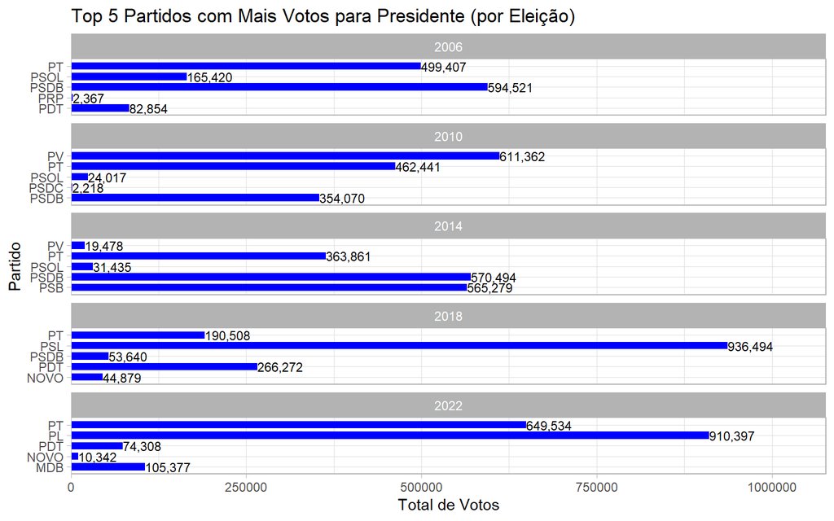

```r
# Criar gráfico
ggplot(

  # Definir qual dataframe será usado no gráfico (nesse caso o de mais votos no partido para presidente - df_partidos_com_mais_votos_presidente)
  data = df_partidos_com_mais_votos_presidente,

  # Definir quais dados estarão no eixo X e Y
  mapping = aes(x = sigla_partido, y = votos_total)) +

  # Colunas com barras azuis
  geom_col(fill = "blue", width = 0.7) +

  # Adicionar rótulo nas barras
  geom_text(aes(label = scales::comma(votos_total)),
            # Definir posiçao do texto fora da barra:
            hjust = 0,
            # Cor e tamanho do texto
            color = "black",
            size = 3) +

  # Transforma o gráfico em Barras Horizontais
  coord_flip() +

  # Expande a visualização do gráfico no eito Y
  scale_y_continuous(expand = expansion(mult = c(0, 0.15))) +

  # Adiciona mais espaçamento no eito X
  scale_x_discrete(expand = expansion(add = 0.7)) +

  # Cria a visualização para cada ano
  facet_wrap(~ ano, ncol = 1, scales = "free_y") +

  # Rótulos
  theme_light() +
  labs(
    title = "Top 5 Partidos com Mais Votos para Presidente (por Eleição)",
    x = "Partido",
    y = "Total de Votos"
  )
```

Análise do cenário de 2006 a 2022 para os 5 partidos mais votados para presidente:

1. Naufrágio do PSDB no DF
- Teve seu auge entre 2006 a 2014 no DF. O PSDB era uma força dominante. Venceu em 2006 (Alckmin) e 2014 (Aécio), e foi competitivo em 2010 (Serra). O DF era um reduto tucano clássico.
- Em 2018, os votos no PSDB encolheram para míseros 53 mil votos (Geraldo Alckmin).
- Provavelmente o eleitor de direita do DF trocou de legenda. Os votos que eram do PSDB migraram quase integralmente para o PSL (2018) e PL (2022) com o movimento bolsonarista. Além disso, nesses anos, se intensificou a narrativa de que o PSDB nunca foi um partido verdadeiramente de direita.
2. Marina Silva como alternativa para a esquerda
- Em 2010 e 2014, o PV e o PSB (ambos tendo Marina como candidata a presidência) arrecadaram uma quantidade competitiva de votos.
- Isso mostra que o DF flertou com intensidade com uma alternativa progressista/ambientalista antes de guinar para a direita conservadora em 2018.
3. DF nunca permitiu uma consolidação do PT
- O pior momento da história do PT no DF foi 2018, caindo para menos de 200 mil votos e ficando atrás do Ciro Gomes (candidato que fez uma campanha intensa pelo PDT para se apresentar como uma terceira via para o Brasil).
- 2022 mostra a força do “Lulismo” e o impacto da polarização no DF. O PT saltou de 190k para 649k votos. Embora não tenha vencido o PL, o PT triplicou seu tamanho em relação à eleição anterior, recuperando o eleitorado que havia perdido para Ciro ou brancos/nulos.
4. Consolidação do Bolsonarismo
- Estabilidade do voto bolsonarista aponta para uma fidelidade altíssima do eleitor ao Bolsonaro.Em 2018 (PSL): 936.494 votos. E em 2022 (PL): 910.397 votos.
- Isso indica um eleitorado muito convicto e consolidado, difícil de ser penetrado pela esquerda.

#### Top 5 Partidos que mais recebem votos por ano para o cargo de Deputado Distrital

O código usado para fazer essa análise é o mesmo que foi usado para presidente, então será repetido o mesmo código só com a alteração de nome do Dataframe e do filtro utilizado para obter os dados só para deputado distrital.

```r
# Criar dataframe para deputados distritais
df_partidos_com_mais_votos_deputado <- df_resultado_eleicao %>%
  filter(cargo == "deputado distrital") %>%
  group_by(sigla_partido, ano) %>%
  summarise(votos_total = sum(votos)) %>%
  arrange(ano, desc(votos_total)) %>%
  group_by(ano) %>%
  slice_head(n = 5)
```

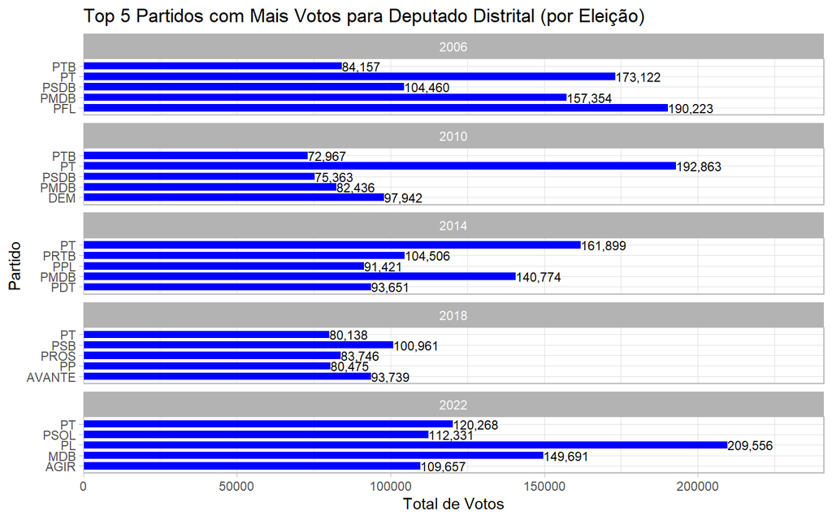

```r
# Criar gráfico
ggplot(
  data = df_partidos_com_mais_votos_deputado,
  mapping = aes(x = sigla_partido, y = votos_total)) +

  geom_col(fill = "blue", width = 0.7) +

  geom_text(aes(label = scales::comma(votos_total)),
            hjust = 0,
            color = "black",
            size = 3) +

  coord_flip() +

  scale_y_continuous(expand = expansion(mult = c(0, 0.15))) +

  scale_x_discrete(expand = expansion(add = 0.7)) +

  facet_wrap(~ ano, ncol = 1, scales = "free_y") +

  theme_light() +
  labs(
    title = "Top 5 Partidos com Mais Votos para Deputado Distrital (por Eleição)",
    x = "Partido",
    y = "Total de Votos"
  )
```

Análise do poder legislativo no DF por partido (2006–2022):

1. Direita Tradicional consolidada até 2014
- Auge do PFL, barra do PFL com 190.223 votos em 2006, que virou DEM e depois União Brasil dominava a política local.
- o PFL/DEM/União Brasil desaparece do Top 5 a partir de 2014. Esse vácuo de poder na direita tradicional abriu espaço para o que veríamos em 2018 e 2022.
2. Consistênia do MDB
- O partido aparece forte em 2006, 2010, 2014 e 2022.
- Mesmo com a onda nacional da era PT (2006-2014) ou Bolsonaro (2022), o MDB manteve sua bancada legislativa sólida, garantindo governabilidade (ou oposição forte) a qualquer governador.
3. PT se mantém vivo como partido
- Em 2010, o PT atingiu seu pico (192.863 votos), impulsionado pela eleição de Agnelo Queiroz para governador e a popularidade de Lula.
- Em 2018, o reflexo do impeachment e da Lava Jato foi brutal. O PT caiu para 80.138 votos. Perderam mais da metade do eleitorado legislativo em comparação a 201o e metade dos votos comparado a 2014.
- Em 2022, o partido volta a crescer para 120.268 votos, estabilizando-se como uma força média-grande, mas longe da hegemonia de outrora.
4. 2018 como ano atípico
- Em 2018, não houve um partido dominante disparado.
- Novas siglas aparecem como protagonistas dessa eleição.Isso reflete o voto de protesto contra a “velha política” (PT e PSDB/MDB), que acabou dispersando votos para legendas do “Centrão”.
5. Nacionalização do voto distrital
- O Partido Liberal bateu o recorde histórico do PFL de 2006 no período analisado.
- Pela primeira vez, o PSOL entra no Top 5 do DF.Grande parte dos votos no PSOL se deve a um fenômeno chamado Fábio Felix, que teve votação recorde (~51 mil votos). Isso mostra que a esquerda no DF renovou seus quadros.

#### Top 3 Partidos que mais recebem votos por RA para Presidente em 2006

Os anos seguintes também seguirão o mesmo padrão de código, só havera mudança no ano. E depois no cargo, quando for a análise para deputado distrital.

```r
# Criar o Dataframe com os dados dos top 3 partidos mais votados para presidente por zona em 2006
df_mais_votos_patido_por_zona_2006 <- df_resultado_eleicao %>%
  filter(cargo == "presidente", ano == 2006) %>%
  group_by(sigla_partido, zona) %>%
  summarise(votos_total = sum(votos)) %>%
  arrange(zona, desc(votos_total)) %>%
  group_by(zona) %>%
  slice_head(n = 3)
```

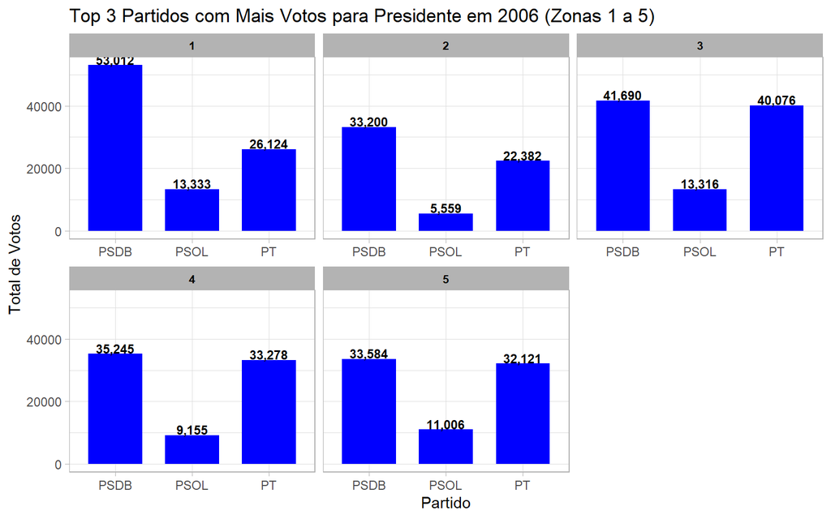

```r
# Criar gráfico das zonas 1 a 6
ggplot(
  # Definir qual dataframe será usado no gráfico (nesse caso o de mais votos no partido para presidente - df_partidos_com_mais_votos_presidente)
  data = df_mais_votos_patido_por_zona_2006 %>% filter(zona < 6),

  # Definir quais dados estarão no eixo X e Y
  mapping = aes(x = sigla_partido, y = votos_total)) +

  # Colunas com barras azuis
  geom_col(fill = "blue", width = 0.7) +

  # Adicionar rótulo nas barras
  geom_text(aes(label = scales::comma(votos_total)),
            # Cor e tamanho do texto
            hjust = 0.5,
            vjust = -0.1,
            color = "black",
            size = 3,
            fontface = "bold") +

  # Cria a visualização para cada ano
  facet_wrap(~ zona, scales = "free_x") +

  # Rótulos
  theme_light() +
  labs(
    title = "Top 3 Partidos com Mais Votos para Presidente em 2006 (Zonas 1 a 5)",
    x = "Partido",
    y = "Total de Votos"
  ) +
theme(
  # Títulos dos painéis (strips)
  strip.text = element_text(
    face = "bold",
    color = "black",
    size = 8)
)
```

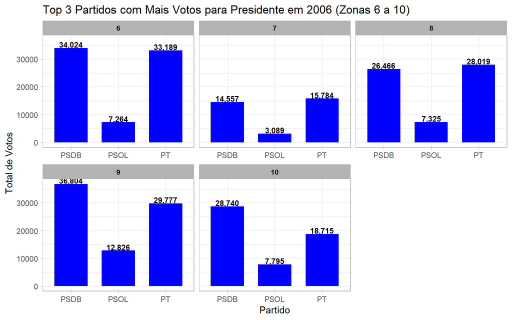

```r
# Criar gráfico das zonas 6 a 11
ggplot(
  data = df_mais_votos_patido_por_zona_2006 %>% filter(zona > 5 & zona < 11),
  mapping = aes(x = sigla_partido, y = votos_total)) +

  geom_col(fill = "blue", width = 0.7) +

  geom_text(aes(label = scales::comma(votos_total)),
            hjust = 0.5,
            vjust = -0.1,
            color = "black",
            size = 3,
            fontface = "bold") +

  facet_wrap(~ zona, scales = "free_x") +

  theme_light() +
  labs(
    title = "Top 3 Partidos com Mais Votos para Presidente em 2006 (Zonas 6 a 10)",
    x = "Partido",
    y = "Total de Votos"
  ) +
theme(
  strip.text = element_text(
    face = "bold",
    color = "black",
    size = 8)
)
```

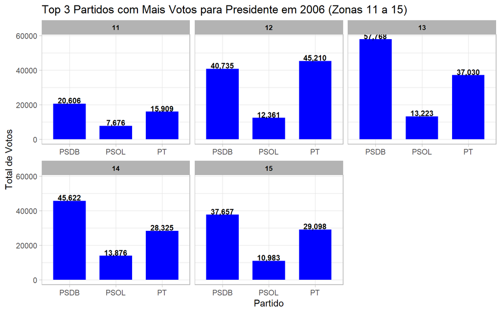

```r
# Criar gráfico das zonas de 13 a 19
ggplot(
  data = df_mais_votos_patido_por_zona_2006 %>% filter(zona > 10 & zona < 16),
  mapping = aes(x = sigla_partido, y = votos_total)) +

  geom_col(fill = "blue", width = 0.7) +

  geom_text(aes(label = scales::comma(votos_total)),
            hjust = 0.5,
            vjust = -0.1,
            color = "black",
            size = 3,
            fontface = "bold") +

  facet_wrap(~ zona, scales = "free_x") +

  theme_light() +
  labs(
    title = "Top 3 Partidos com Mais Votos para Presidente em 2006 (Zonas 11 a 15)",
    x = "Partido",
    y = "Total de Votos"
  ) +
theme(
  strip.text = element_text(
    face = "bold",
    color = "black",
    size = 8)
)
```

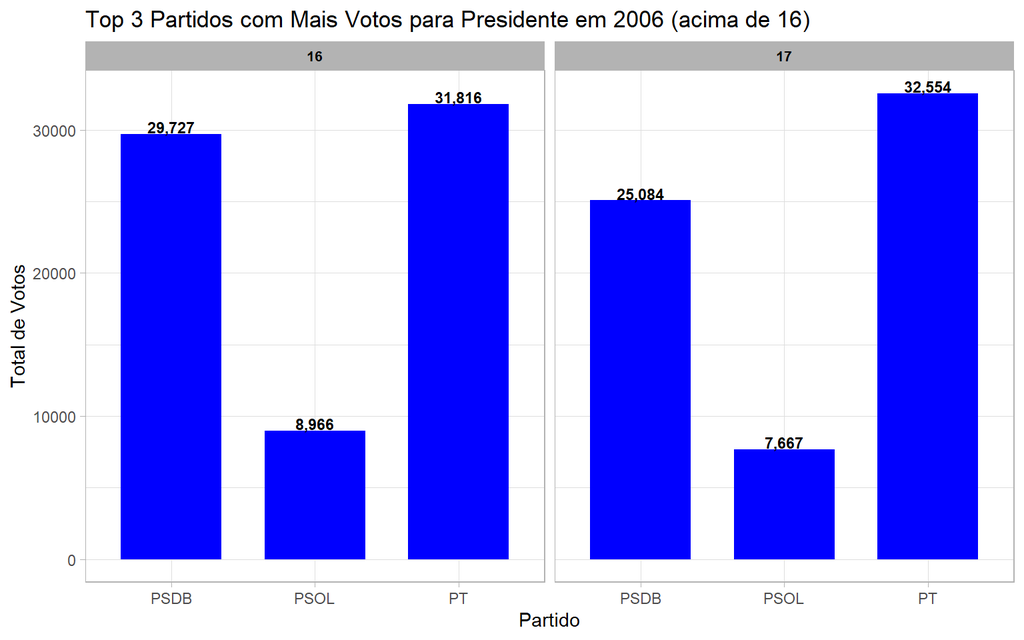

```r
# Criar gráfico das zonas acima de 15
ggplot(
  data = df_mais_votos_patido_por_zona_2006 %>% filter(zona > 15),
  mapping = aes(x = sigla_partido, y = votos_total)) +

  geom_col(fill = "blue", width = 0.7) +

  geom_text(aes(label = scales::comma(votos_total)),
            hjust = 0.5,
            vjust = -0.1,
            color = "black",
            size = 3,
            fontface = "bold") +

  facet_wrap(~ zona, scales = "free_x") +

  theme_light() +
  labs(
    title = "Top 3 Partidos com Mais Votos para Presidente em 2006 (acima de 16)",
    x = "Partido",
    y = "Total de Votos"
  ) +
theme(
  strip.text = element_text(
    face = "bold",
    color = "black",
    size = 8)
)
```

#### Top 3 Partidos que mais recebem votos por RA para Presidente em 2010

```r
# Criar o Dataframe com os dados dos top 3 partidos mais votados para presidente por zona em 2010
df_mais_votos_patido_por_zona_2010 <- df_resultado_eleicao %>%
  filter(cargo == "presidente", ano == 2010) %>%
  group_by(sigla_partido, zona) %>%
  summarise(votos_total = sum(votos)) %>%
  arrange(zona, desc(votos_total)) %>%
  group_by(zona) %>%
  slice_head(n = 3)
```

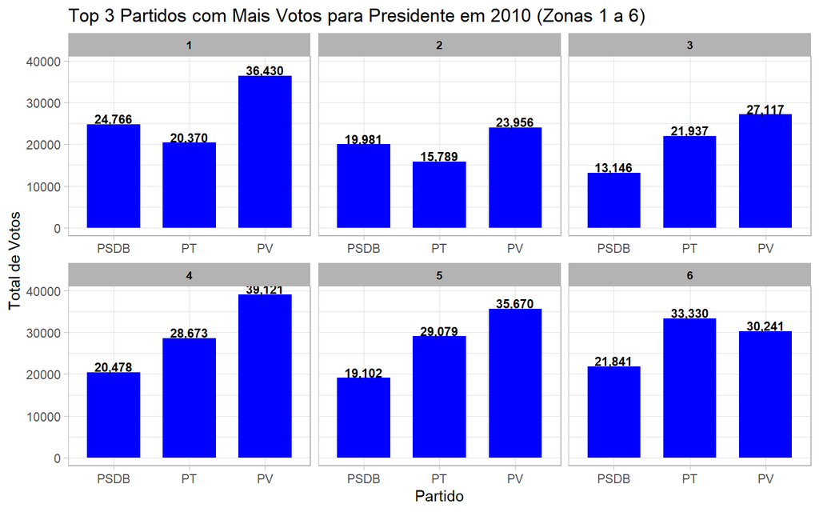

```r
# Criar gráfico das zonas 1 a 6
ggplot(
  data = df_mais_votos_patido_por_zona_2010 %>% filter(zona < 7),
  mapping = aes(x = sigla_partido, y = votos_total)) +
  geom_col(fill = "blue", width = 0.7) +
  geom_text(aes(label = scales::comma(votos_total)),
            hjust = 0.5,
            vjust = -0.1,
            color = "black",
            size = 3,
            fontface = "bold") +
  facet_wrap(~ zona, scales = "free_x") +
  theme_light() +
  labs(
    title = "Top 3 Partidos com Mais Votos para Presidente em 2010 (Zonas 1 a 6)",
    x = "Partido",
    y = "Total de Votos"
  ) +
theme(
  strip.text = element_text(
    face = "bold",
    color = "black",
    size = 8)
)
```

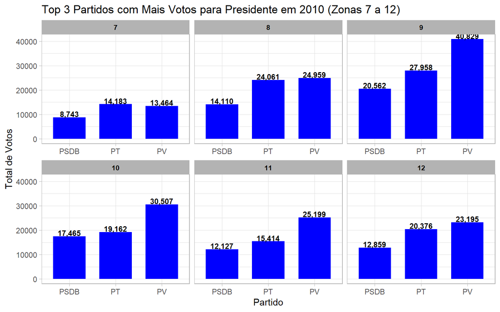

```r
# Criar gráfico das zonas 6 a 11
ggplot(
  data = df_mais_votos_patido_por_zona_2010 %>% filter(zona > 6 & zona < 13),
  mapping = aes(x = sigla_partido, y = votos_total)) +
  geom_col(fill = "blue", width = 0.7) +
  geom_text(aes(label = scales::comma(votos_total)),
            hjust = 0.5,
            vjust = -0.1,
            color = "black",
            size = 3,
            fontface = "bold") +
  facet_wrap(~ zona, scales = "free_x") +
  theme_light() +
  labs(
    title = "Top 3 Partidos com Mais Votos para Presidente em 2010 (Zonas 7 a 12)",
    x = "Partido",
    y = "Total de Votos"
  ) +
theme(
  strip.text = element_text(
    face = "bold",
    color = "black",
    size = 8)
)
```

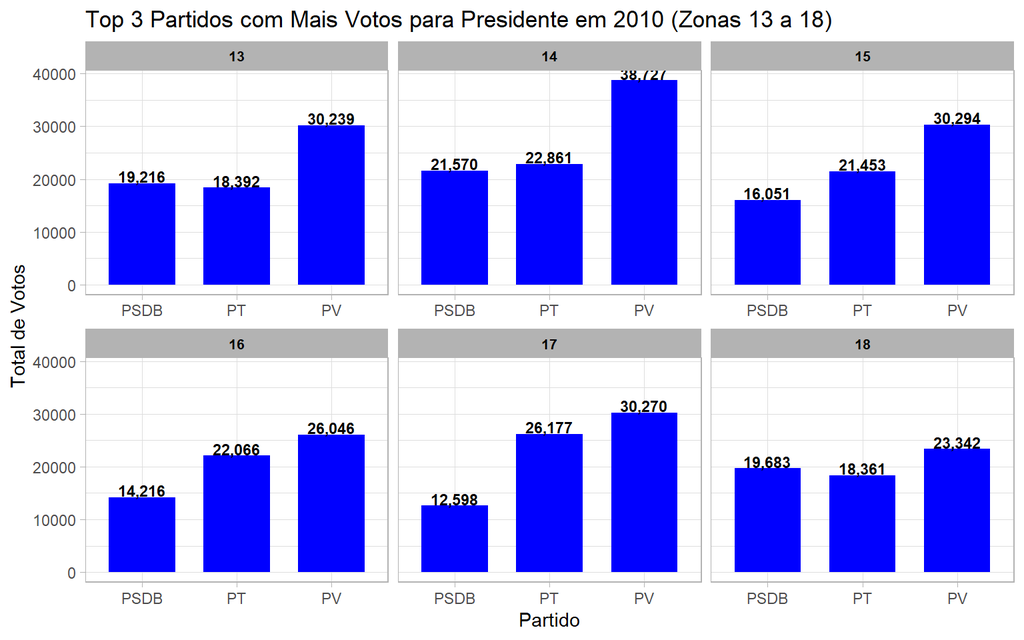

```r
# Criar gráfico das zonas de 13 a 19
ggplot(
  data = df_mais_votos_patido_por_zona_2010 %>% filter(zona > 12 & zona < 19),
  mapping = aes(x = sigla_partido, y = votos_total)) +
  geom_col(fill = "blue", width = 0.7) +
  geom_text(aes(label = scales::comma(votos_total)),
            hjust = 0.5,
            vjust = -0.1,
            color = "black",
            size = 3,
            fontface = "bold") +
  facet_wrap(~ zona, scales = "free_x") +
  theme_light() +
  labs(
    title = "Top 3 Partidos com Mais Votos para Presidente em 2010 (Zonas 13 a 18)",
    x = "Partido",
    y = "Total de Votos"
  ) +
theme(
  strip.text = element_text(
    face = "bold",
    color = "black",
    size = 8)
)
```

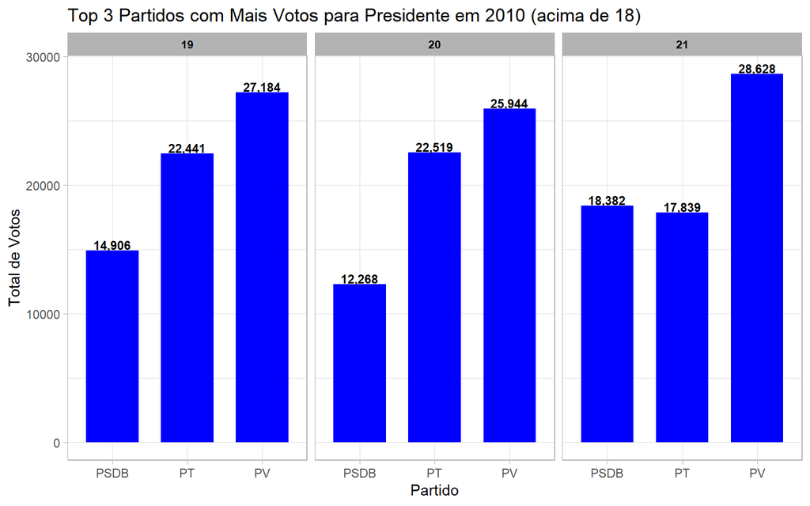

```r
# Criar gráfico das zonas acima de 19
ggplot(
  data = df_mais_votos_patido_por_zona_2010 %>% filter(zona > 18),
  mapping = aes(x = sigla_partido, y = votos_total)) +
  geom_col(fill = "blue", width = 0.7) +
  geom_text(aes(label = scales::comma(votos_total)),
            hjust = 0.5,
            vjust = -0.1,
            color = "black",
            size = 3,
            fontface = "bold") +
  facet_wrap(~ zona, scales = "free_x") +
  theme_light() +
  labs(
    title = "Top 3 Partidos com Mais Votos para Presidente em 2010 (acima de 18)",
    x = "Partido",
    y = "Total de Votos"
  ) +
theme(
  strip.text = element_text(
    face = "bold",
    color = "black",
    size = 8)
)
```

Os gráficos de 2010 revelam o momento mais singular da história política do DF no período analisado:

#### Top 3 Partidos que mais recebem votos por RA para Presidente em 2014

```r
# Criar o Dataframe com os dados dos top 3 partidos mais votados para presidente por zona em 2014
df_mais_votos_patido_por_zona_2014 <- df_resultado_eleicao %>%
  filter(cargo == "presidente", ano == 2014) %>%
  group_by(sigla_partido, zona) %>%
  summarise(votos_total = sum(votos)) %>%
  arrange(zona, desc(votos_total)) %>%
  group_by(zona) %>%
  slice_head(n = 3)
```

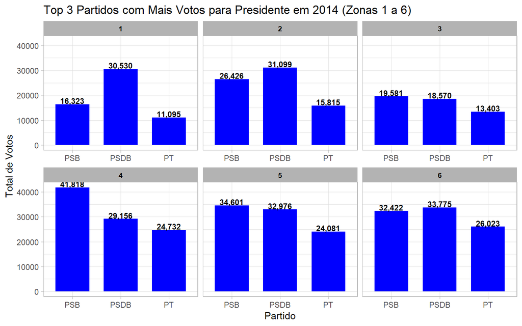

```r
# Criar gráfico das zonas 1 a 6
ggplot(
  data = df_mais_votos_patido_por_zona_2014 %>% filter(zona < 7),
  mapping = aes(x = sigla_partido, y = votos_total)) +
  geom_col(fill = "blue", width = 0.7) +
  geom_text(aes(label = scales::comma(votos_total)),
            hjust = 0.5,
            vjust = -0.1,
            color = "black",
            size = 3,
            fontface = "bold") +
  facet_wrap(~ zona, scales = "free_x") +
  theme_light() +
  labs(
    title = "Top 3 Partidos com Mais Votos para Presidente em 2014 (Zonas 1 a 6)",
    x = "Partido",
    y = "Total de Votos"
  ) +
theme(
  strip.text = element_text(
    face = "bold",
    color = "black",
    size = 8)
)
```

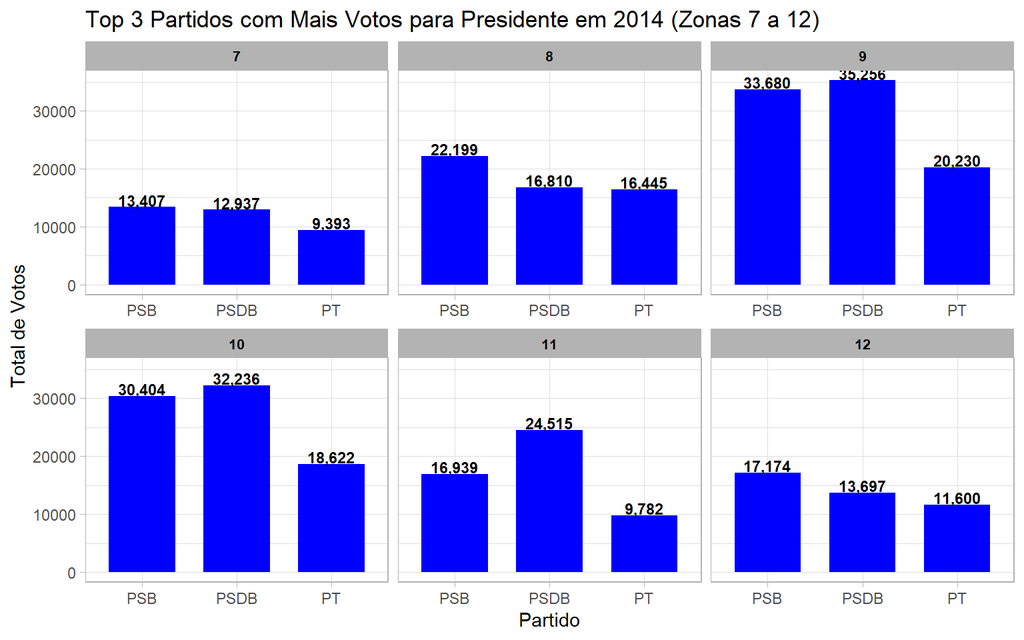

```r
# Criar gráfico das zonas 6 a 11
ggplot(
  data = df_mais_votos_patido_por_zona_2014 %>% filter(zona > 6 & zona < 13),
  mapping = aes(x = sigla_partido, y = votos_total)) +
  geom_col(fill = "blue", width = 0.7) +
  geom_text(aes(label = scales::comma(votos_total)),
            hjust = 0.5,
            vjust = -0.1,
            color = "black",
            size = 3,
            fontface = "bold") +
  facet_wrap(~ zona, scales = "free_x") +
  theme_light() +
  labs(
    title = "Top 3 Partidos com Mais Votos para Presidente em 2014 (Zonas 7 a 12)",
    x = "Partido",
    y = "Total de Votos"
  ) +
theme(
  strip.text = element_text(
    face = "bold",
    color = "black",
    size = 8)
)
```

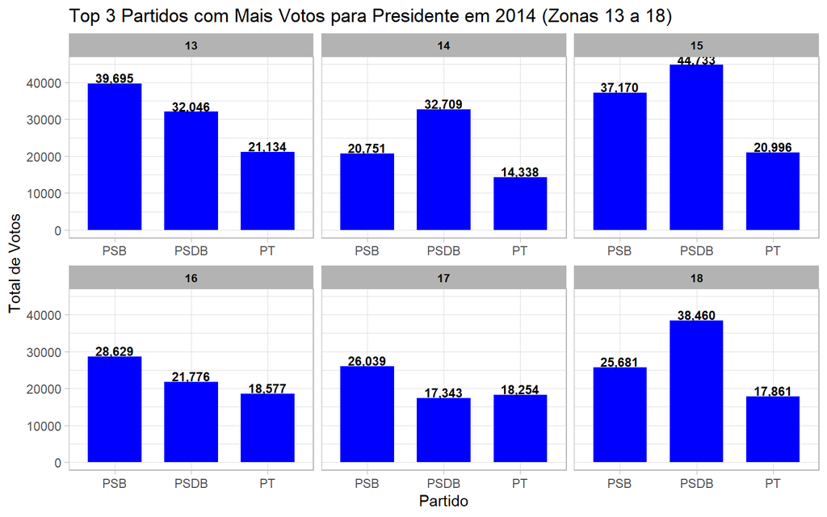

```r
# Criar gráfico das zonas de 13 a 19
ggplot(
  data = df_mais_votos_patido_por_zona_2014 %>% filter(zona > 12 & zona < 19),
  mapping = aes(x = sigla_partido, y = votos_total)) +
  geom_col(fill = "blue", width = 0.7) +
  geom_text(aes(label = scales::comma(votos_total)),
            hjust = 0.5,
            vjust = -0.1,
            color = "black",
            size = 3,
            fontface = "bold") +
  facet_wrap(~ zona, scales = "free_x") +
  theme_light() +
  labs(
    title = "Top 3 Partidos com Mais Votos para Presidente em 2014 (Zonas 13 a 18)",
    x = "Partido",
    y = "Total de Votos"
  ) +
theme(
  strip.text = element_text(
    face = "bold",
    color = "black",
    size = 8)
)
```

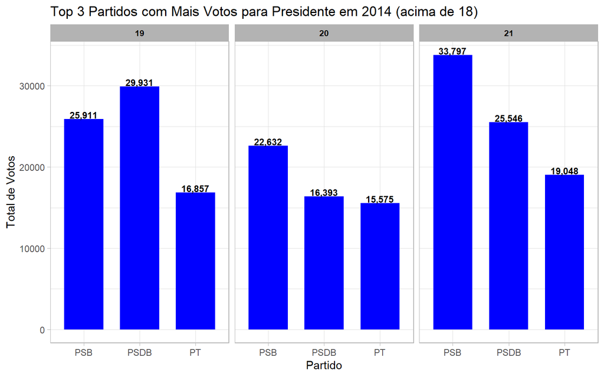

```r
# Criar gráfico das zonas acima de 19
ggplot(
  data = df_mais_votos_patido_por_zona_2014 %>% filter(zona > 18),
  mapping = aes(x = sigla_partido, y = votos_total)) +
  geom_col(fill = "blue", width = 0.7) +
  geom_text(aes(label = scales::comma(votos_total)),
            hjust = 0.5,
            vjust = -0.1,
            color = "black",
            size = 3,
            fontface = "bold") +

  facet_wrap(~ zona, scales = "free_x") +
  theme_light() +
  labs(
    title = "Top 3 Partidos com Mais Votos para Presidente em 2014 (acima de 18)",
    x = "Partido",
    y = "Total de Votos"
  ) +
theme(
  strip.text = element_text(
    face = "bold",
    color = "black",
    size = 8)
)
```

Os gráficos de 2014 mostram que a dinâmica no DF mudou bastante em relação a eleição de 2010:

1. A classe média alta, que havia flertado com Marina em 2010, voltou para o ninho tucano.A morte de Eduardo Campos e a súbita ascensão de Marina geraram uma incerteza estratégica.
2. Apesar da elite ter voltado ao PSDB, Marina (PSB) manteve e até expandiu sua força em algumas Cidades Satélites.
3. A presença de Marina/PSB em todas as Zonas como a primeira ou segunda força impediu que o PT se recuperasse, mantendo o partido na terceira posição em quase todos as zonas.

#### Top 3 Partidos que mais recebem votos por RA para Presidente em 2018

```r
# Criar o Dataframe com os dados dos top 3 partidos mais votados para presidente por zona em 2018
df_mais_votos_patido_por_zona_2018 <- df_resultado_eleicao %>%
  filter(cargo == "presidente", ano == 2018) %>%
  group_by(sigla_partido, zona) %>%
  summarise(votos_total = sum(votos)) %>%
  arrange(zona, desc(votos_total)) %>%
  group_by(zona) %>%
  slice_head(n = 3)
```

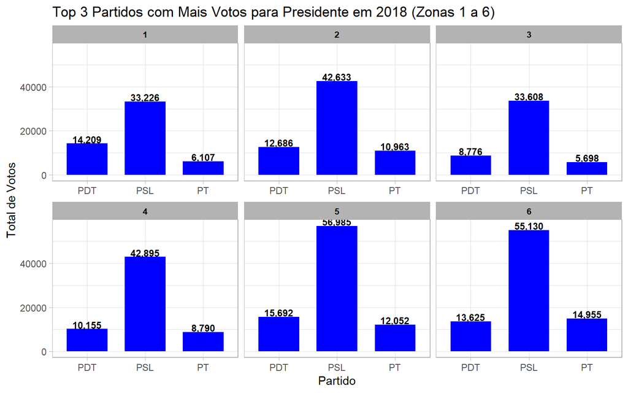

```r
# Criar gráfico das zonas 1 a 6
ggplot(
  data = df_mais_votos_patido_por_zona_2018 %>% filter(zona < 7),
  mapping = aes(x = sigla_partido, y = votos_total)) +
  geom_col(fill = "blue", width = 0.7) +
  geom_text(aes(label = scales::comma(votos_total)),
            hjust = 0.5,
            vjust = -0.1,
            color = "black",
            size = 3,
            fontface = "bold") +
  facet_wrap(~ zona, scales = "free_x") +
  theme_light() +
  labs(
    title = "Top 3 Partidos com Mais Votos para Presidente em 2018 (Zonas 1 a 6)",
    x = "Partido",
    y = "Total de Votos"
  ) +
theme(
  strip.text = element_text(
    face = "bold",
    color = "black",
    size = 8)
)
```

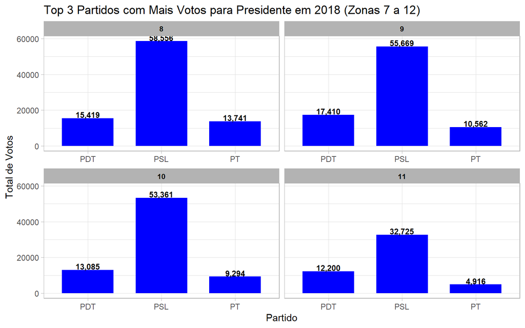

```r
# Criar gráfico das zonas 6 a 11
ggplot(
  data = df_mais_votos_patido_por_zona_2018 %>% filter(zona > 6 & zona < 13),
  mapping = aes(x = sigla_partido, y = votos_total)) +
  geom_col(fill = "blue", width = 0.7) +
  geom_text(aes(label = scales::comma(votos_total)),
            hjust = 0.5,
            vjust = -0.1,
            color = "black",
            size = 3,
            fontface = "bold") +
  facet_wrap(~ zona, scales = "free_x") +
  theme_light() +
  labs(
    title = "Top 3 Partidos com Mais Votos para Presidente em 2018 (Zonas 7 a 12)",
    x = "Partido",
    y = "Total de Votos"
  ) +
theme(
  strip.text = element_text(
    face = "bold",
    color = "black",
    size = 8)
)
```

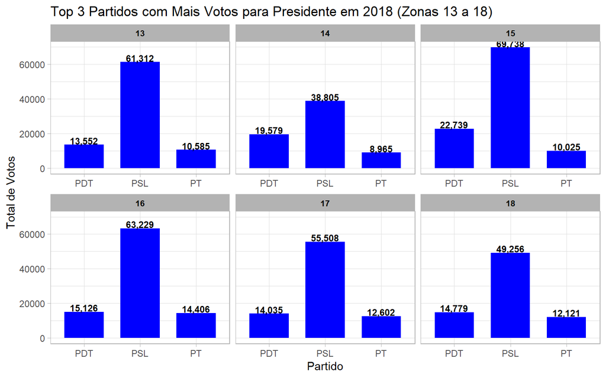

```r
# Criar gráfico das zonas de 13 a 19
ggplot(
  data = df_mais_votos_patido_por_zona_2018 %>% filter(zona > 12 & zona < 19),
  mapping = aes(x = sigla_partido, y = votos_total)) +
  geom_col(fill = "blue", width = 0.7) +
  geom_text(aes(label = scales::comma(votos_total)),
            hjust = 0.5,
            vjust = -0.1,
            color = "black",
            size = 3,
            fontface = "bold") +
  facet_wrap(~ zona, scales = "free_x") +
  theme_light() +
  labs(
    title = "Top 3 Partidos com Mais Votos para Presidente em 2018 (Zonas 13 a 18)",
    x = "Partido",
    y = "Total de Votos"
  ) +
theme(
  strip.text = element_text(
    face = "bold",
    color = "black",
    size = 8)
)
```

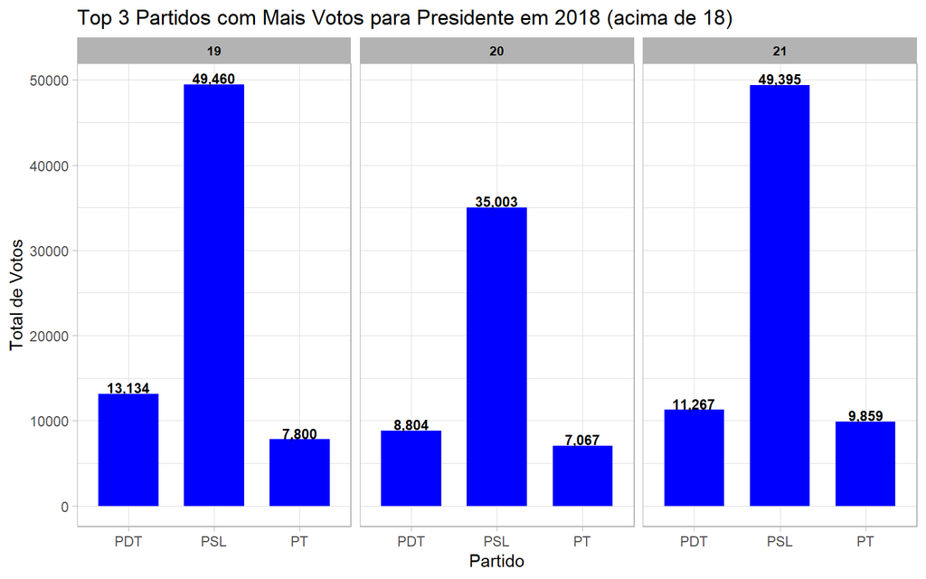

```r
# Criar gráfico das zonas acima de 19
ggplot(
  data = df_mais_votos_patido_por_zona_2018 %>% filter(zona > 18),
  mapping = aes(x = sigla_partido, y = votos_total)) +
  geom_col(fill = "blue", width = 0.7) +
  geom_text(aes(label = scales::comma(votos_total)),
            hjust = 0.5,
            vjust = -0.1,
            color = "black",
            size = 3,
            fontface = "bold") +
  facet_wrap(~ zona, scales = "free_x") +
  theme_light() +
  labs(
    title = "Top 3 Partidos com Mais Votos para Presidente em 2018 (acima de 18)",
    x = "Partido",
    y = "Total de Votos"
  ) +
theme(
  strip.text = element_text(
    face = "bold",
    color = "black",
    size = 8)
)
```

Os gráficos de 2018 mostram a ruptura do padrão eleitoral do DF, marcando o fim do ciclo PSDB vs. PT (2006) e do voto volátil de terceira via (2010/2014).

1. O PSL (Bolsonaro) venceu em absolutamente todas as Zonas Eleitorais, desde Plano Piloto até a periferia. O PSL não apenas venceu, mas o fez com uma distância considerável dos votos do PT, consolidando o DF como a capital do antipetismo.
2. A onda antipetista provou ser forte o suficiente para virar até mesmo as Cidades Satélites, que votaram em Lula (2006) ou Marina (2014), agora votando em Bolsonaro. Isso mostra que o voto popular de direita no DF se consolidou muito além do Plano Piloto.

#### Top 3 Partidos que mais recebem votos por RA para Presidente em 2022

```r
# Criar o Dataframe com os dados dos top 3 partidos mais votados para presidente por zona em 2022
df_mais_votos_patido_por_zona_2022 <- df_resultado_eleicao %>%
  filter(cargo == "presidente", ano == 2022) %>%
  group_by(sigla_partido, zona) %>%
  summarise(votos_total = sum(votos)) %>%
  arrange(zona, desc(votos_total)) %>%
  group_by(zona) %>%
  slice_head(n = 3)
```

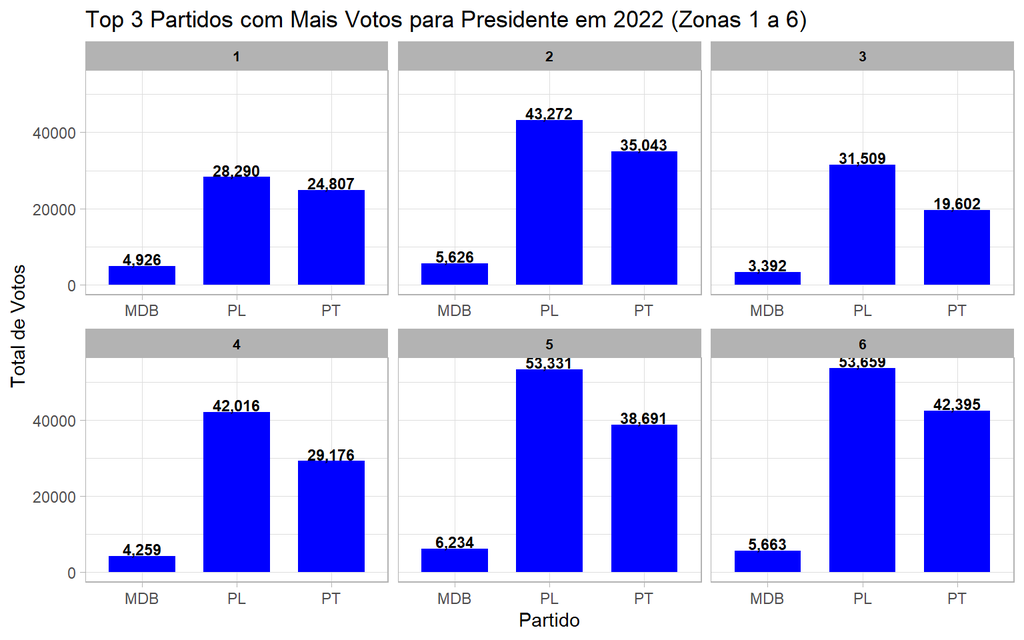

```r
# Criar gráfico das zonas 1 a 6
ggplot(
  data = df_mais_votos_patido_por_zona_2022 %>% filter(zona < 7),
  mapping = aes(x = sigla_partido, y = votos_total)) +
  geom_col(fill = "blue", width = 0.7) +
  geom_text(aes(label = scales::comma(votos_total)),
            hjust = 0.5,
            vjust = -0.1,
            color = "black",
            size = 3,
            fontface = "bold") +
  facet_wrap(~ zona, scales = "free_x") +
  theme_light() +
  labs(
    title = "Top 3 Partidos com Mais Votos para Presidente em 2022 (Zonas 1 a 6)",
    x = "Partido",
    y = "Total de Votos"
  ) +
theme(
  strip.text = element_text(
    face = "bold",
    color = "black",
    size = 8)
)
```

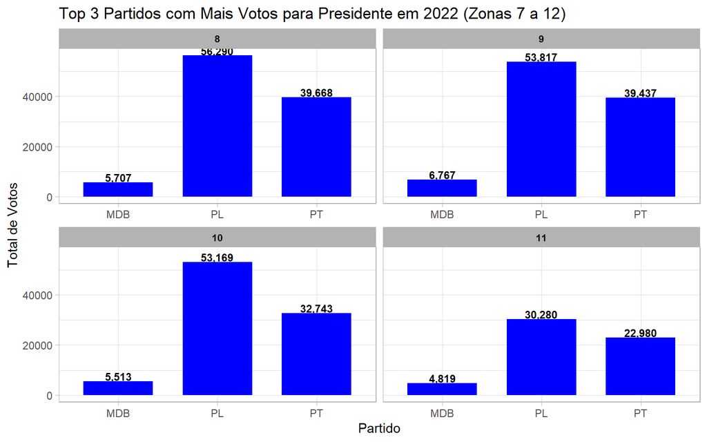

```r
# Criar gráfico das zonas 6 a 11
ggplot(
  data = df_mais_votos_patido_por_zona_2022 %>% filter(zona > 6 & zona < 13),
  mapping = aes(x = sigla_partido, y = votos_total)) +
  geom_col(fill = "blue", width = 0.7) +
  geom_text(aes(label = scales::comma(votos_total)),
            hjust = 0.5,
            vjust = -0.1,
            color = "black",
            size = 3,
            fontface = "bold") +
  facet_wrap(~ zona, scales = "free_x") +
  theme_light() +
  labs(
    title = "Top 3 Partidos com Mais Votos para Presidente em 2022 (Zonas 7 a 12)",
    x = "Partido",
    y = "Total de Votos"
  ) +
theme(
  strip.text = element_text(
    face = "bold",
    color = "black",
    size = 8)
)
```

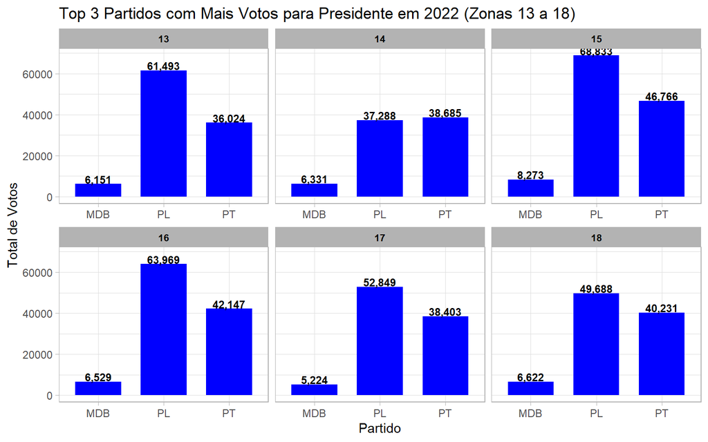

```r
# Criar gráfico das zonas de 13 a 19
ggplot(
  data = df_mais_votos_patido_por_zona_2022 %>% filter(zona > 12 & zona < 19),
  mapping = aes(x = sigla_partido, y = votos_total)) +
  geom_col(fill = "blue", width = 0.7) +
  geom_text(aes(label = scales::comma(votos_total)),
            hjust = 0.5,
            vjust = -0.1,
            color = "black",
            size = 3,
            fontface = "bold") +
  facet_wrap(~ zona, scales = "free_x") +
  theme_light() +
  labs(
    title = "Top 3 Partidos com Mais Votos para Presidente em 2022 (Zonas 13 a 18)",
    x = "Partido",
    y = "Total de Votos"
  ) +
theme(
  strip.text = element_text(
    face = "bold",
    color = "black",
    size = 8)
)
```

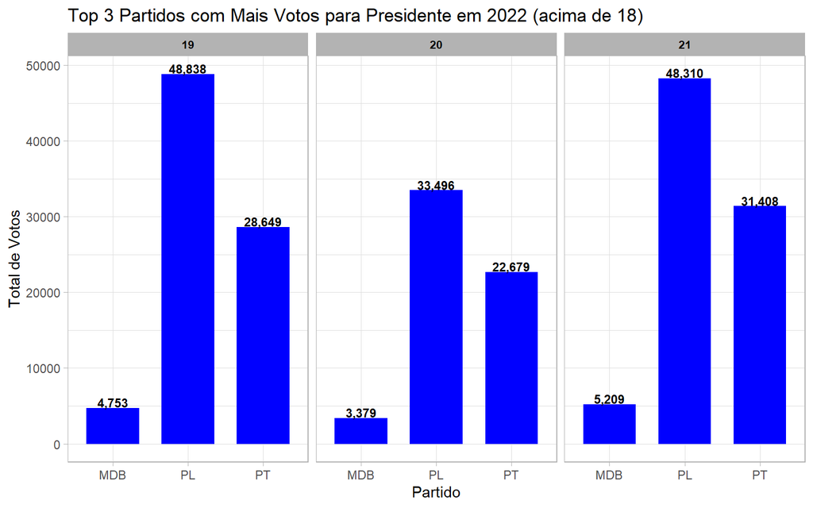

```r
# Criar gráfico das zonas acima de 19
ggplot(
  data = df_mais_votos_patido_por_zona_2022 %>% filter(zona > 18),
  mapping = aes(x = sigla_partido, y = votos_total)) +
  geom_col(fill = "blue", width = 0.7) +
  geom_text(aes(label = scales::comma(votos_total)),
            hjust = 0.5,
            vjust = -0.1,
            color = "black",
            size = 3,
            fontface = "bold") +
  facet_wrap(~ zona, scales = "free_x") +
  theme_light() +
  labs(
    title = "Top 3 Partidos com Mais Votos para Presidente em 2022 (acima de 18)",
    x = "Partido",
    y = "Total de Votos"
  ) +
theme(
  strip.text = element_text(
    face = "bold",
    color = "black",
    size = 8)
)
```

Os gráficos de 2022 mostram a consolidação da polarização ideológica do DF.

1. Ao contrário de 2018 (onde só o PSL dominava), agora temos o retorno do PT com força, resultando em um mapa dividido de forma mais clara. Embora o PL ainda ganhe na maioria das zonas.
2. A Morte da Terceira Via. O eleitor do DF demonstrou que, ao contrário dos ciclos anteriores, agora buscava apenas o candidato com maior chance de vencer o polo oposto.

#### Top 3 Partidos que mais recebem votos por RA para Deputado Distrital em 2006

```r
# Criar o Dataframe com os dados dos top 3 partidos mais votados para Deputado Distrital por zona em 2006
df_mais_votos_patido_deputado_por_zona_2006 <- df_resultado_eleicao %>%
  filter(cargo == "deputado distrital", ano == 2006) %>%
  group_by(sigla_partido, zona) %>%
  summarise(votos_total = sum(votos)) %>%
  arrange(zona, desc(votos_total)) %>%
  group_by(zona) %>%
  slice_head(n = 3)
```

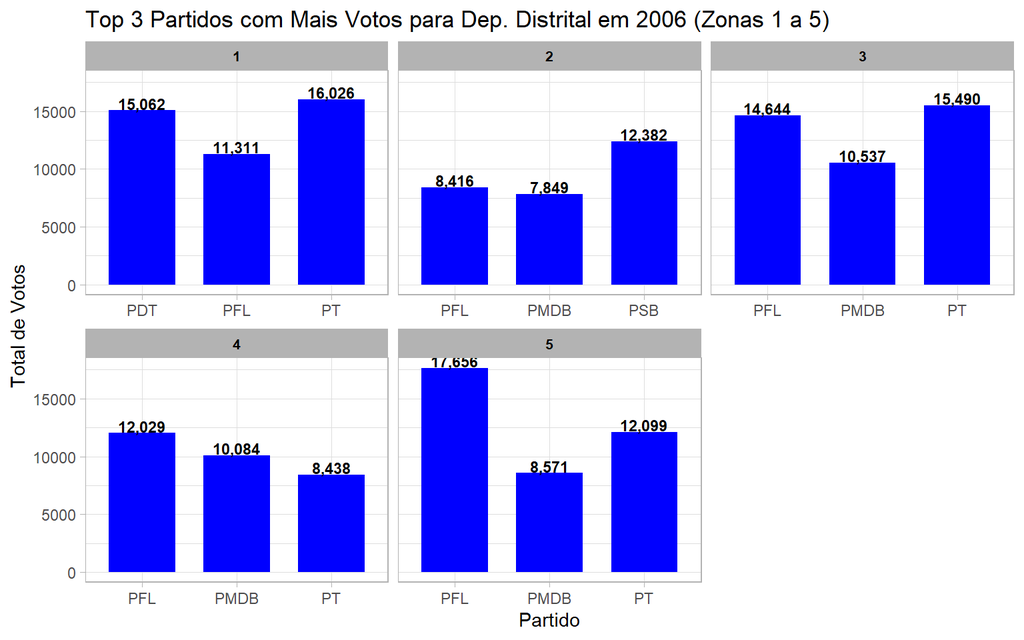

```r
# Criar gráfico das zonas 1 a 6
ggplot(
  data = df_mais_votos_patido_deputado_por_zona_2006 %>% filter(zona < 6),
  mapping = aes(x = sigla_partido, y = votos_total)) +
  geom_col(fill = "blue", width = 0.7) +
  geom_text(aes(label = scales::comma(votos_total)),
            hjust = 0.5,
            vjust = -0.1,
            color = "black",
            size = 3,
            fontface = "bold") +
  facet_wrap(~ zona, scales = "free_x") +
  theme_light() +
  labs(
    title = "Top 3 Partidos com Mais Votos para Dep. Distrital em 2006 (Zonas 1 a 5)",
    x = "Partido",
    y = "Total de Votos"
  ) +
theme(
  strip.text = element_text(
    face = "bold",
    color = "black",
    size = 8)
)
```

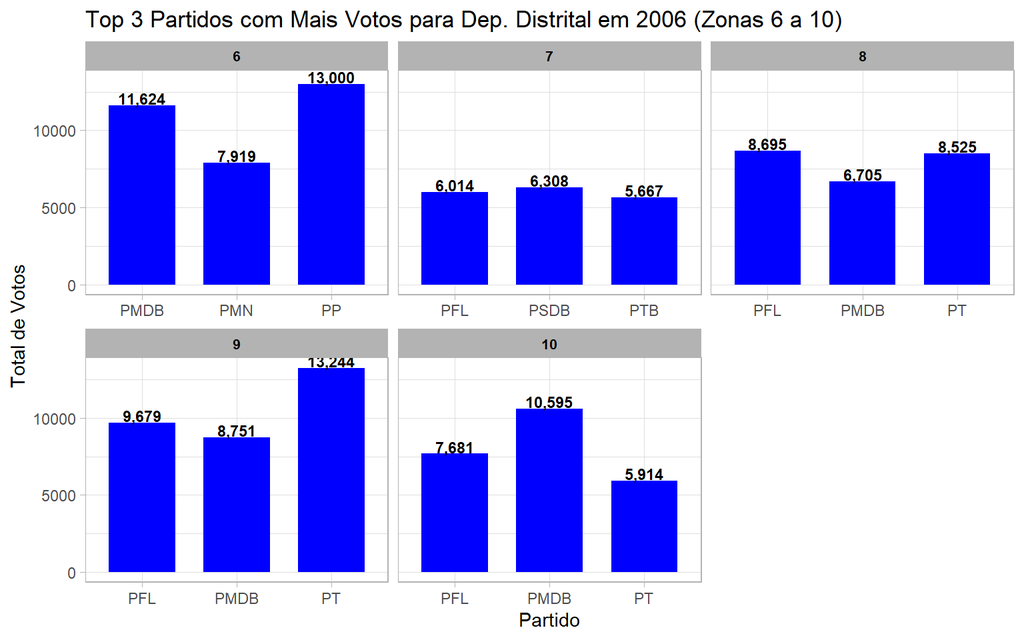

```r
# Criar gráfico das zonas 6 a 11
ggplot(
  data = df_mais_votos_patido_deputado_por_zona_2006 %>% filter(zona > 5 & zona < 11),
  mapping = aes(x = sigla_partido, y = votos_total)) +

  geom_col(fill = "blue", width = 0.7) +

  geom_text(aes(label = scales::comma(votos_total)),
            hjust = 0.5,
            vjust = -0.1,
            color = "black",
            size = 3,
            fontface = "bold") +

  facet_wrap(~ zona, scales = "free_x") +

  theme_light() +
  labs(
    title = "Top 3 Partidos com Mais Votos para Dep. Distrital em 2006 (Zonas 6 a 10)",
    x = "Partido",
    y = "Total de Votos"
  ) +
theme(
  strip.text = element_text(
    face = "bold",
    color = "black",
    size = 8)
)
```

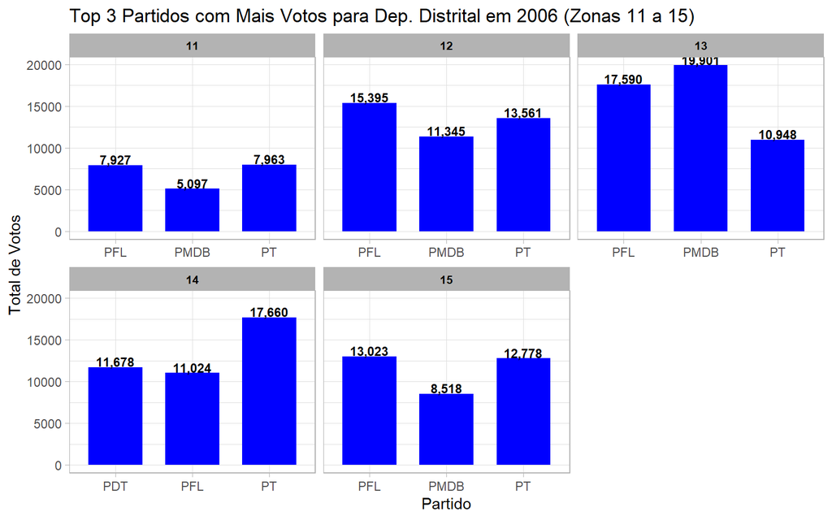

```r
# Criar gráfico das zonas de 13 a 19
ggplot(
  data = df_mais_votos_patido_deputado_por_zona_2006 %>% filter(zona > 10 & zona < 16),
  mapping = aes(x = sigla_partido, y = votos_total)) +

  geom_col(fill = "blue", width = 0.7) +

  geom_text(aes(label = scales::comma(votos_total)),
            hjust = 0.5,
            vjust = -0.1,
            color = "black",
            size = 3,
            fontface = "bold") +

  facet_wrap(~ zona, scales = "free_x") +

  theme_light() +
  labs(
    title = "Top 3 Partidos com Mais Votos para Dep. Distrital em 2006 (Zonas 11 a 15)",
    x = "Partido",
    y = "Total de Votos"
  ) +
theme(
  strip.text = element_text(
    face = "bold",
    color = "black",
    size = 8)
)
```

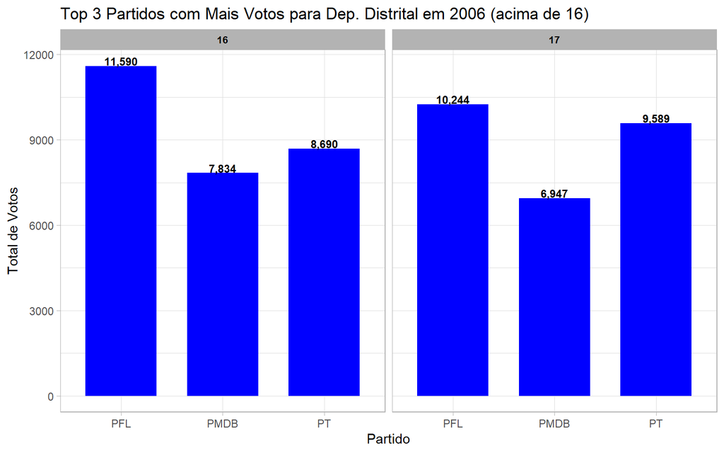

```r
# Criar gráfico das zonas acima de 15
ggplot(
  data = df_mais_votos_patido_deputado_por_zona_2006 %>% filter(zona > 15),
  mapping = aes(x = sigla_partido, y = votos_total)) +

  geom_col(fill = "blue", width = 0.7) +

  geom_text(aes(label = scales::comma(votos_total)),
            hjust = 0.5,
            vjust = -0.1,
            color = "black",
            size = 3,
            fontface = "bold") +

  facet_wrap(~ zona, scales = "free_x") +

  theme_light() +
  labs(
    title = "Top 3 Partidos com Mais Votos para Dep. Distrital em 2006 (acima de 16)",
    x = "Partido",
    y = "Total de Votos"
  ) +
theme(
  strip.text = element_text(
    face = "bold",
    color = "black",
    size = 8)
)
```

Alguns pontos que podemos analisar baseado nos gráficos de 2006 para Deputado Distrital:

1.O principal padrão observado é a desconexão entre o Executivo (Presidente) e o Legislativo (Distrital).

2. O PFL, partido do governador eleito (José Roberto Arruda) e sucessor do grupo político Roriz/Arruda, demonstra uma força eleitoral robusta.
3. O PT, embora derrotado na maioria das Zonas para Presidente, demonstra ser o único partido de esquerda com capilaridade suficiente para competir localmente.

#### Top 3 Partidos que mais recebem votos por RA para Deputado Distrital em 2010

```r
# Criar o Dataframe com os dados dos top 3 partidos mais votados para Deputado Distrital por zona em 2010
df_mais_votos_patido_deputado_por_zona_2010 <- df_resultado_eleicao %>%
  filter(cargo == "deputado distrital", ano == 2010) %>%
  group_by(sigla_partido, zona) %>%
  summarise(votos_total = sum(votos)) %>%
  arrange(zona, desc(votos_total)) %>%
  group_by(zona) %>%
  slice_head(n = 3)
```

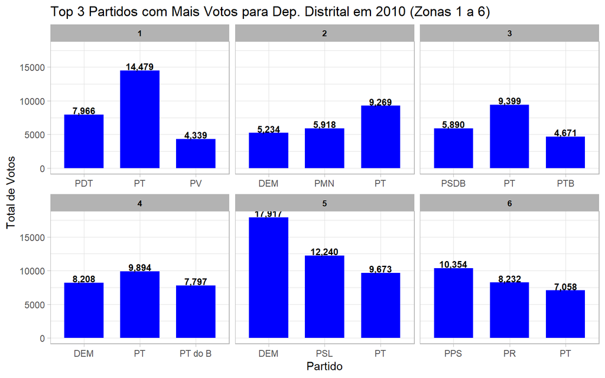

```r
# Criar gráfico das zonas 1 a 6
ggplot(
  data = df_mais_votos_patido_deputado_por_zona_2010 %>% filter(zona < 7),
  mapping = aes(x = sigla_partido, y = votos_total)) +
  geom_col(fill = "blue", width = 0.7) +
  geom_text(aes(label = scales::comma(votos_total)),
            hjust = 0.5,
            vjust = -0.1,
            color = "black",
            size = 3,
            fontface = "bold") +
  facet_wrap(~ zona, scales = "free_x") +
  theme_light() +
  labs(
    title = "Top 3 Partidos com Mais Votos para Dep. Distrital em 2010 (Zonas 1 a 6)",
    x = "Partido",
    y = "Total de Votos"
  ) +
theme(
  strip.text = element_text(
    face = "bold",
    color = "black",
    size = 8)
)
```

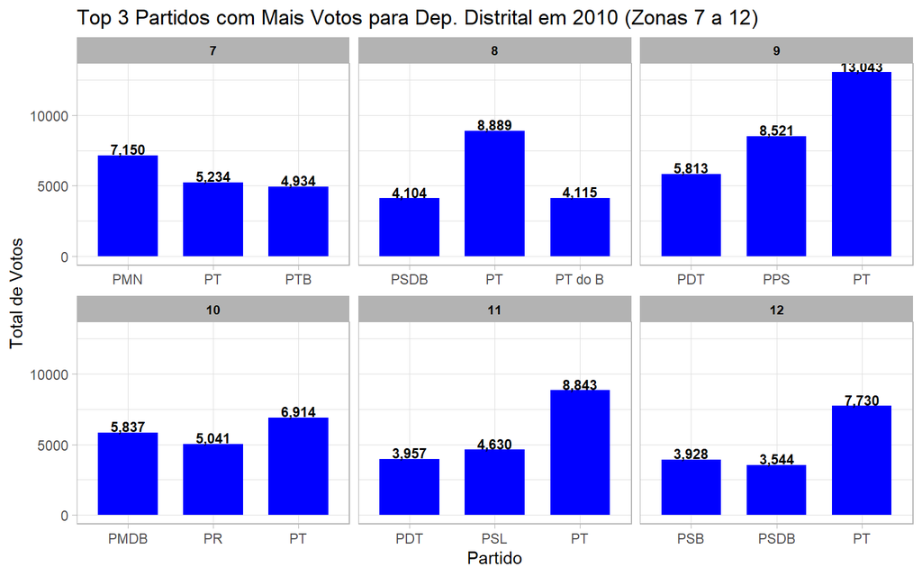

```r
# Criar gráfico das zonas 6 a 11
ggplot(
  data = df_mais_votos_patido_deputado_por_zona_2010 %>% filter(zona > 6 & zona < 13),
  mapping = aes(x = sigla_partido, y = votos_total)) +
  geom_col(fill = "blue", width = 0.7) +
  geom_text(aes(label = scales::comma(votos_total)),
            hjust = 0.5,
            vjust = -0.1,
            color = "black",
            size = 3,
            fontface = "bold") +
  facet_wrap(~ zona, scales = "free_x") +
  theme_light() +
  labs(
    title = "Top 3 Partidos com Mais Votos para Dep. Distrital em 2010 (Zonas 7 a 12)",
    x = "Partido",
    y = "Total de Votos"
  ) +
theme(
  strip.text = element_text(
    face = "bold",
    color = "black",
    size = 8)
)
```

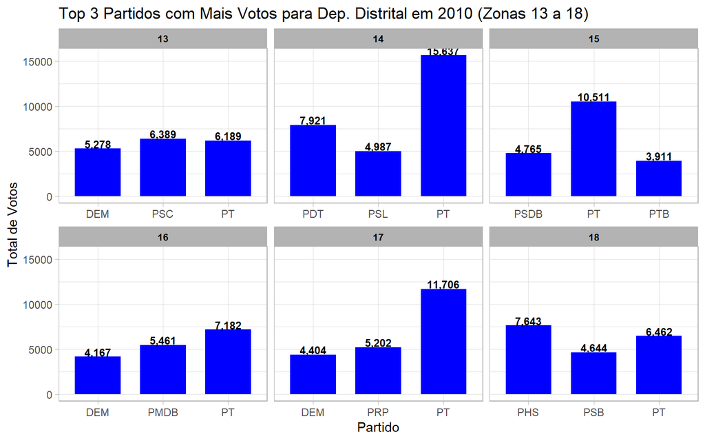

```r
# Criar gráfico das zonas de 13 a 19
ggplot(
  data = df_mais_votos_patido_deputado_por_zona_2010 %>% filter(zona > 12 & zona < 19),
  mapping = aes(x = sigla_partido, y = votos_total)) +
  geom_col(fill = "blue", width = 0.7) +
  geom_text(aes(label = scales::comma(votos_total)),
            hjust = 0.5,
            vjust = -0.1,
            color = "black",
            size = 3,
            fontface = "bold") +
  facet_wrap(~ zona, scales = "free_x") +
  theme_light() +
  labs(
    title = "Top 3 Partidos com Mais Votos para Dep. Distrital em 2010 (Zonas 13 a 18)",
    x = "Partido",
    y = "Total de Votos"
  ) +
theme(
  strip.text = element_text(
    face = "bold",
    color = "black",
    size = 8)
)
```

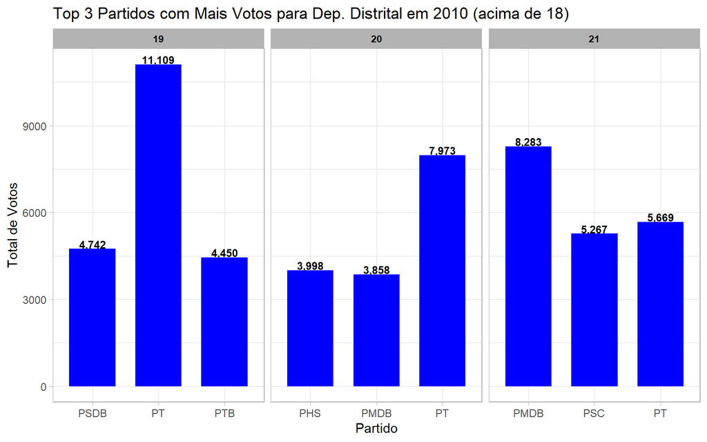

```r
# Criar gráfico das zonas acima de 19
ggplot(
  data = df_mais_votos_patido_deputado_por_zona_2010 %>% filter(zona > 18),
  mapping = aes(x = sigla_partido, y = votos_total)) +
  geom_col(fill = "blue", width = 0.7) +
  geom_text(aes(label = scales::comma(votos_total)),
            hjust = 0.5,
            vjust = -0.1,
            color = "black",
            size = 3,
            fontface = "bold") +
  facet_wrap(~ zona, scales = "free_x") +
  theme_light() +
  labs(
    title = "Top 3 Partidos com Mais Votos para Dep. Distrital em 2010 (acima de 18)",
    x = "Partido",
    y = "Total de Votos"
  ) +
theme(
  strip.text = element_text(
    face = "bold",
    color = "black",
    size = 8)
)
```

Com base nos gráficos da eleição para Deputado Distrital em 2010, podemos afirmar que:

1. Em 2010, o voto para Presidente foi dominado pelo PV, que venceu na maioria das Zonas Eleitorais. No entanto, o voto para Distrital demonstra que o PT absorveu a maior parte desse capital político localmente, enquanto o PV foi irrelevante na eleição para deputado distrital.
2. As estruturas tradicionais de direita e centro-direita (DEM e PMDB) mantiveram sua relevância no voto distrital.